# Using OLS Regression to Predict Median House Values in Philadelphia

CPLN 671 / MUSA 5000: Statistics and Data Mining

Sara Cerami, Gautami Kasat, Tegan Lochner

October 16, 2026

# 1 variables

POLY_ID : Census Block Group ID MEDHVAL : Median value of all owner occupied housing units PCTBACHMOR : Proportion of residents in Block Group with at least a bachelor’s degree PCTVACANT : Proportion of housing units that are vacant PCTSINGLES : Percent of housing units that are detached single family houses NBELPOV100: Number of households with incomes below 100% poverty level (i.e., number of households living in poverty) MEDHHINC : Median household income

```r
options(scipen = 999)

library(Hmisc)
library(DAAG)
library(car)  #to calculate VIF
library(MASS)
library(rsq)
library(tidyverse)
library(caret)
library(dplyr)
library(sf)
library(terra)
library(tmap)
install.packages(c("sf", "terra"))
install.packages("tmap")
# load data and data frame

regression_data <- read.csv("RegressionData.csv")
attach(regression_data)
```

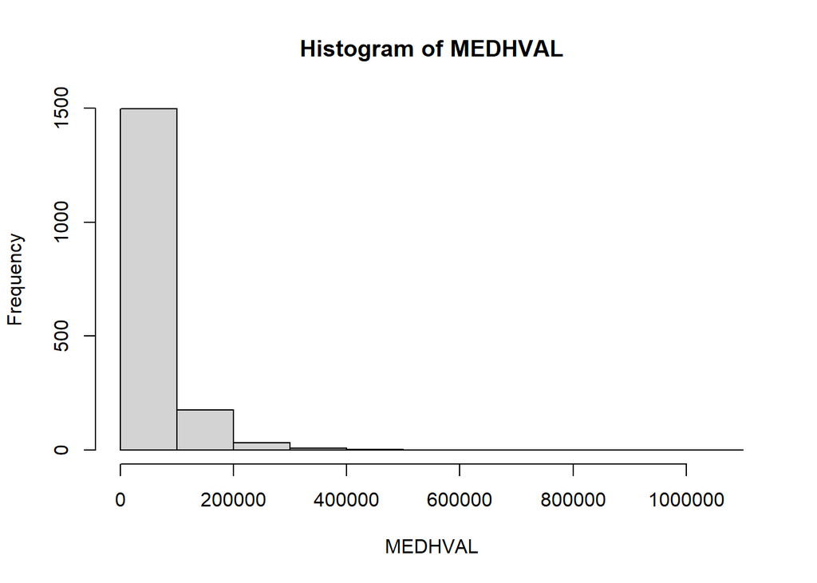

```r
# calculate summary statistics for MEDHVAL

hist(MEDHVAL)
```

```r
mean(MEDHVAL)
```

```
## [1] 66287.73
```

```r
sd(MEDHVAL)
```

```
## [1] 60006.08
```

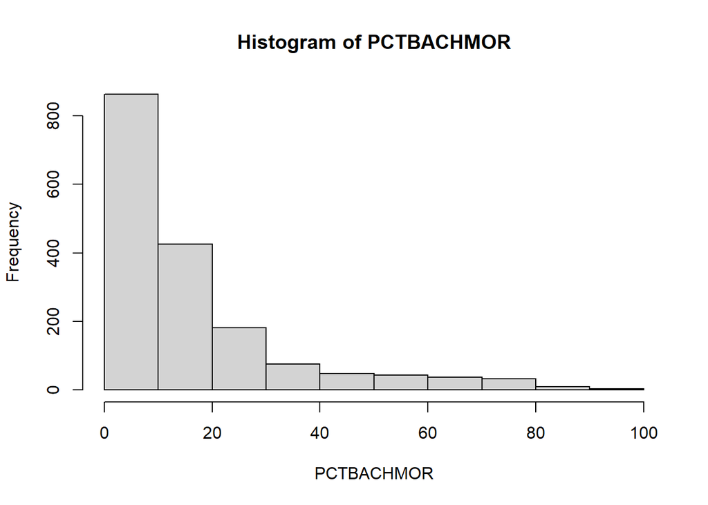

```r
# calculate summary statistics for PCTBACHMOR

hist(PCTBACHMOR)
```

```r
mean(PCTBACHMOR)
```

```
## [1] 16.08137
```

```r
sd(PCTBACHMOR)
```

```
## [1] 17.76956
```

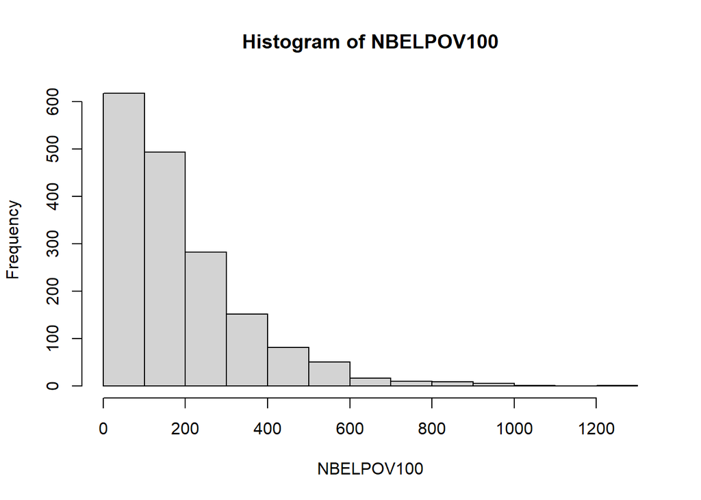

```r
# calculate summary statistics for NBELPOV100

hist(NBELPOV100)
```

```r
mean(NBELPOV100)
```

```
## [1] 189.7709
```

```r
sd(NBELPOV100)
```

```
## [1] 164.3185
```

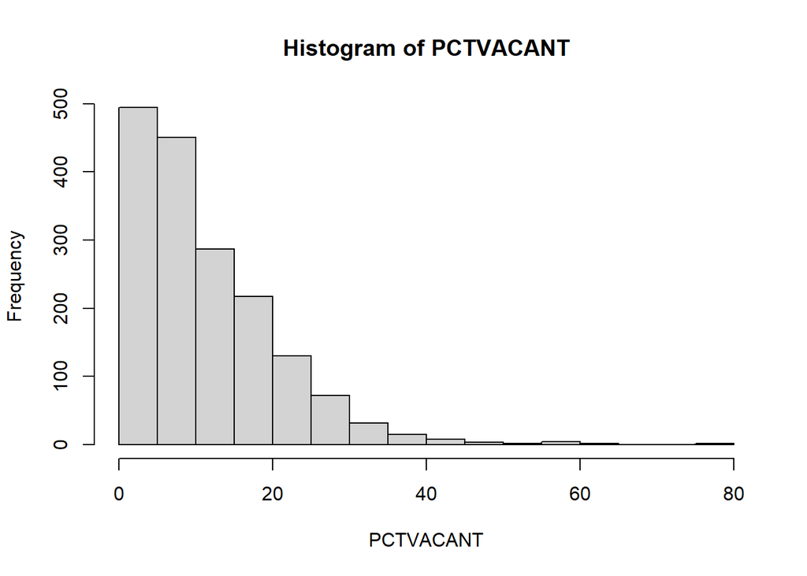

```r
# calculate summary statistics for PCTVACANT

hist(PCTVACANT)
```

```r
mean(PCTVACANT)
```

```
## [1] 11.28853
```

```r
sd(PCTVACANT)
```

```
## [1] 9.628472
```

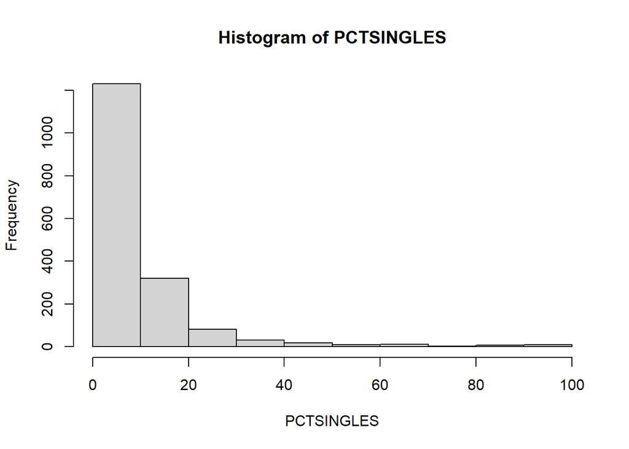

```r
# calculate summary statistics for PCTSINGLES

hist(PCTSINGLES)
```

```r
mean(PCTSINGLES)
```

```
## [1] 9.226473
```

```r
sd(PCTSINGLES)
```

```
## [1] 13.24925
```

```r
# create summary table

summary_table <- data.frame(
  Variable = c(
    "Dependent Variable",
    "MEDHVAL",
    "Predictors",
    "PCTBACHMOR",
    "MEDHHINC",
    "PCTVACANT",
    "PCTSINGLES",
    "NBELPOV100"
  ),
  Mean = c(
    NA,
    mean(MEDHVAL, na.rm = TRUE),
    NA,
    mean(PCTBACHMOR, na.rm = TRUE),
    mean(MEDHHINC, na.rm = TRUE),
    mean(PCTVACANT, na.rm = TRUE),
    mean(PCTSINGLES, na.rm = TRUE),
    mean(NBELPOV100, na.rm = TRUE)
  ),
  SD = c(
    NA,
    sd(MEDHVAL, na.rm = TRUE),
    NA,
    sd(PCTBACHMOR, na.rm = TRUE),
    sd(MEDHHINC, na.rm = TRUE),
    sd(PCTVACANT, na.rm = TRUE),
    sd(PCTSINGLES, na.rm = TRUE),
    sd(NBELPOV100, na.rm = TRUE)
  )
)

summary_table
```

```
##             Variable         Mean           SD
## 1 Dependent Variable           NA           NA
## 2            MEDHVAL 66287.733140 60006.075990
## 3         Predictors           NA           NA
## 4         PCTBACHMOR    16.081372    17.769558
## 5           MEDHHINC 31541.764535 16298.433836
## 6          PCTVACANT    11.288529     9.628472
## 7         PCTSINGLES     9.226473    13.249250
## 8         NBELPOV100   189.770930   164.318480
```

```r
# check if any of the data have any zero values

sapply(regression_data[c("MEDHVAL", "PCTBACHMOR",
                         "PCTVACANT", "PCTSINGLES", "NBELPOV100")],
       function(x) sum(x == 0, na.rm = TRUE))
```

```
##    MEDHVAL PCTBACHMOR  PCTVACANT PCTSINGLES NBELPOV100
##          0        143        163        306         33
```

```r
# use the log command to create 5 new variables

LNMEDHVAL <- log(MEDHVAL)
LNPCTBACHMOR <- log(1+PCTBACHMOR)
LNNBELPOV100 <- log(1+NBELPOV100)
LNPCTVACANT <- log(1+PCTVACANT)
LNPCTSINGLES <- log(1+PCTSINGLES)
```

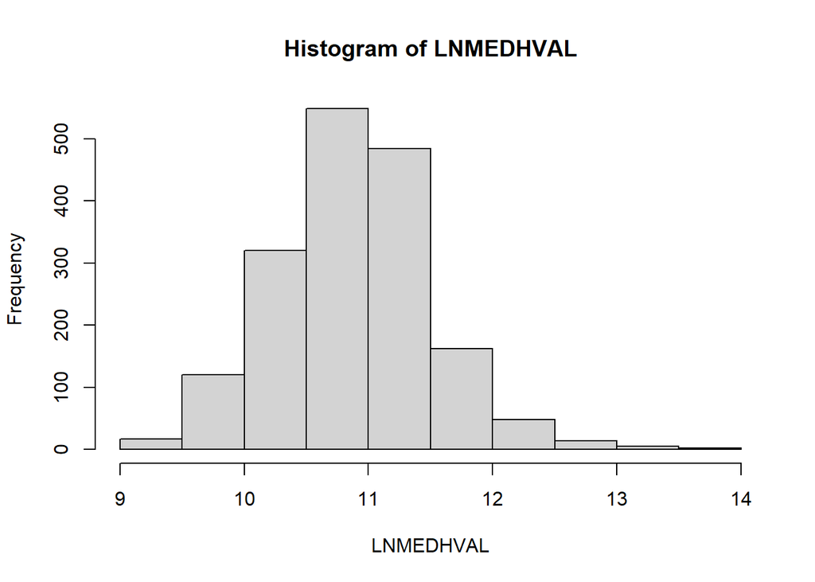

```r
# view the histograms of the new variables

hist(LNMEDHVAL)
```

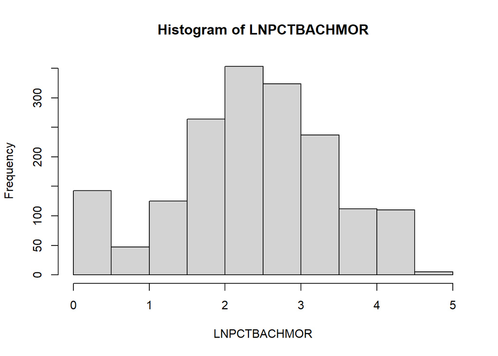

```r
hist(LNPCTBACHMOR)
```

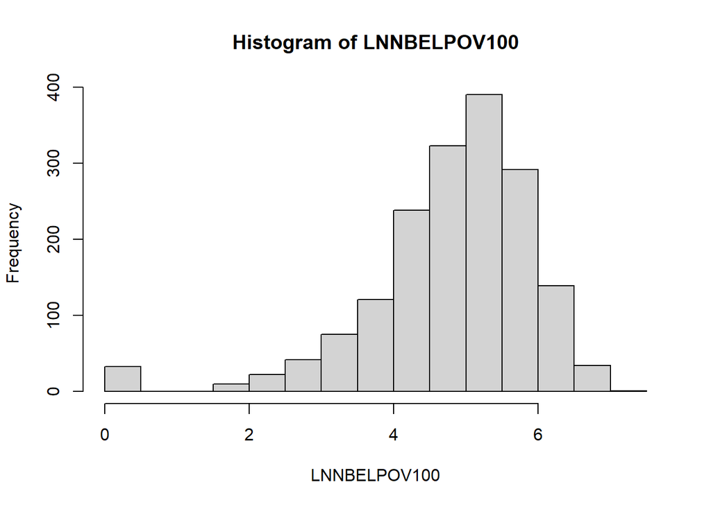

```r
hist(LNNBELPOV100)
```

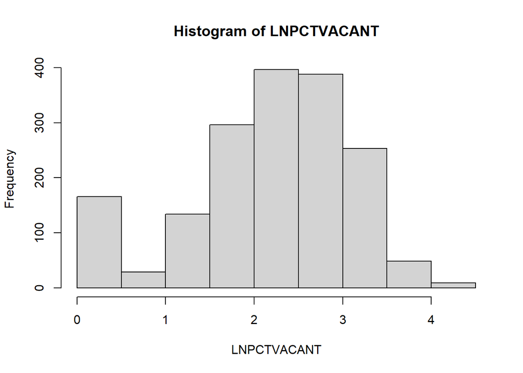

```r
hist(LNPCTVACANT)
```

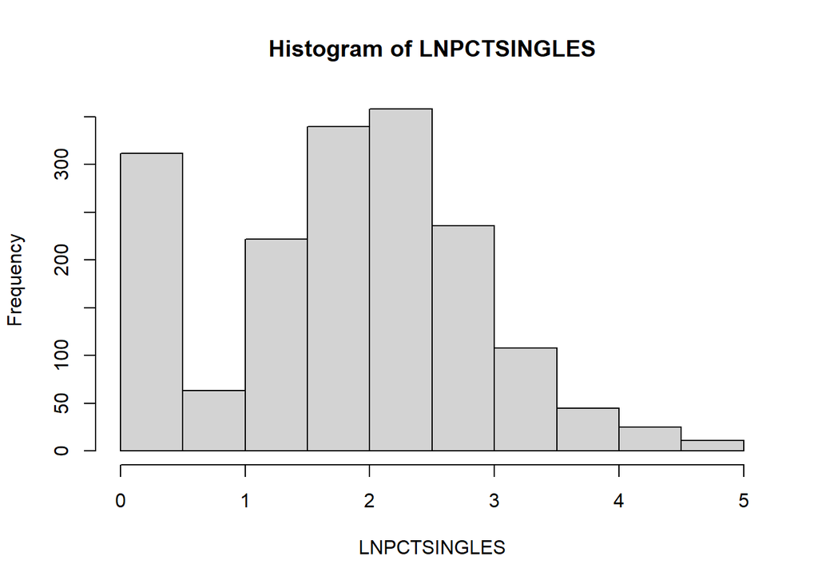

```r
hist(LNPCTSINGLES)
```

Note that the dependent variable does look more or less normal after the transformation – hence, LNMEDHVAL will be used as the dependent variable in the regression analysis. You will also see that for the predictors, the logarithmic transformation only helps normalize the NBELPOV100 variable (so we will use LNNBELPOV100 in the subsequent analyses). The other variables have a large spike at zero (i.e., zero-inflated distributions) after the transformations, so we will use the original, untransformed PCBACHMORE, PCTVACANT, and PCTSINGLES variables in the regression

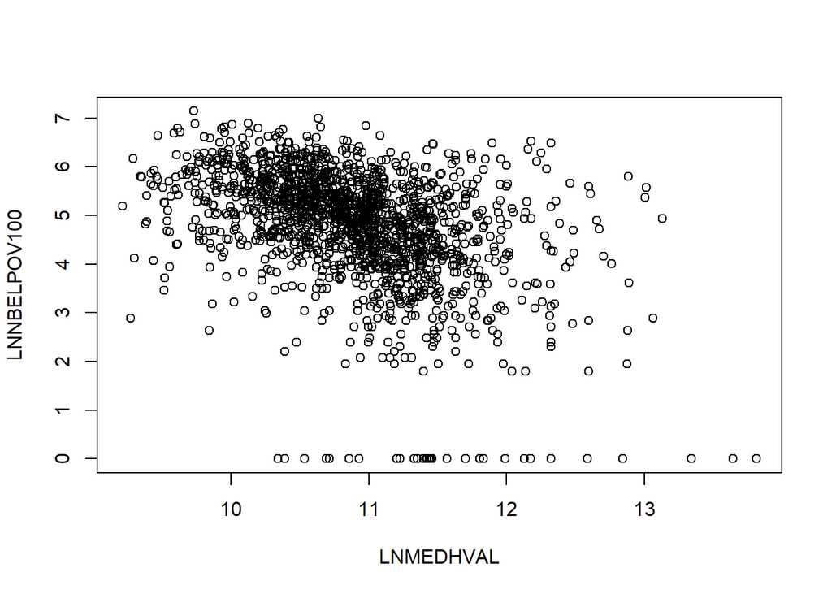

```r
# determine if the relationship between the dependent variables and each of the predictors is linear, create four scatter plots

plot(LNMEDHVAL,LNNBELPOV100)
```

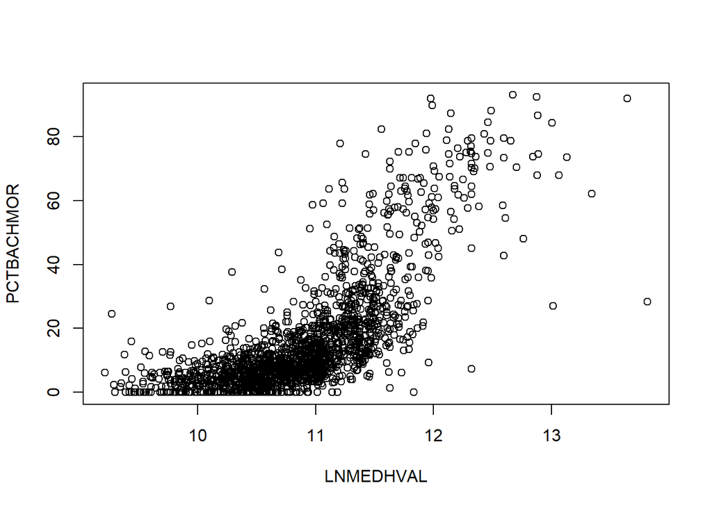

```r
plot(LNMEDHVAL,PCTBACHMOR)
```

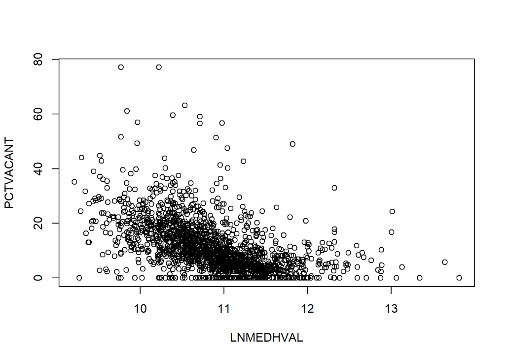

```r
plot(LNMEDHVAL,PCTVACANT)
```

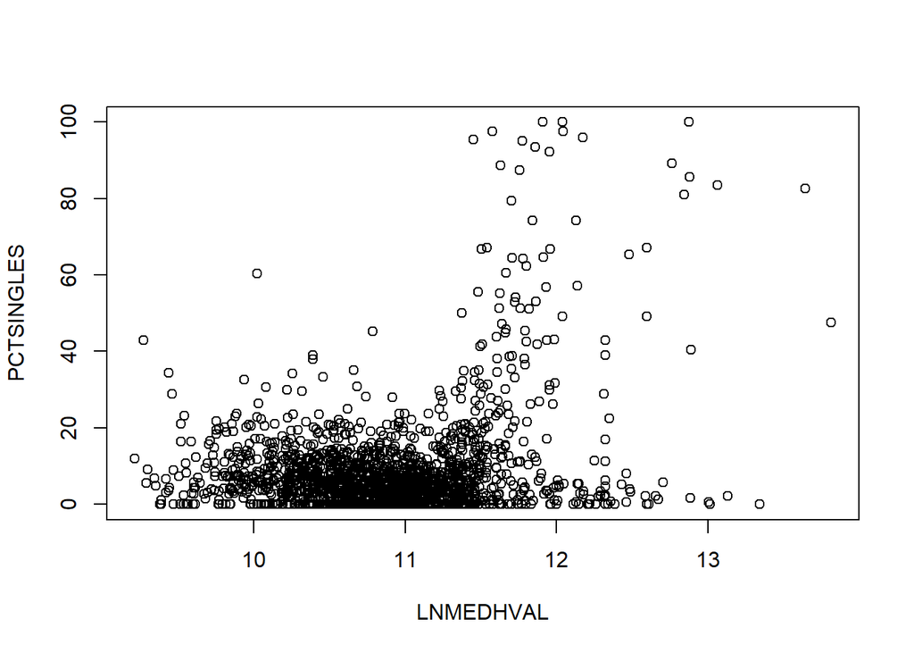

```r
plot(LNMEDHVAL,PCTSINGLES)
```

```r
# check the Pearson correlations between all of the predictors

cor(cbind(PCTVACANT, PCTSINGLES, PCTBACHMOR, LNNBELPOV100))
```

```
##               PCTVACANT PCTSINGLES PCTBACHMOR LNNBELPOV100
## PCTVACANT     1.0000000 -0.1513734 -0.2983580    0.2495470
## PCTSINGLES   -0.1513734  1.0000000  0.1975461   -0.2905159
## PCTBACHMOR   -0.2983580  0.1975461  1.0000000   -0.3197668
## LNNBELPOV100  0.2495470 -0.2905159 -0.3197668    1.0000000
```

Note whether you observe severe multicollinearity, and whether it’s appropriate to include all 4 variables as predictors.

None of the variables show severe multicollinearity. The most severe result is -0.3197668.

```r
# import the shape file

regression_data_shp <- st_read("RegressionDataFiles.shp")
```

```r
# create the map for LNMEDHVAL

tmap_mode("plot")
```

```
## ℹ tmap modes "plot" - "view"
## ℹ toggle with `tmap::ttm()`
```

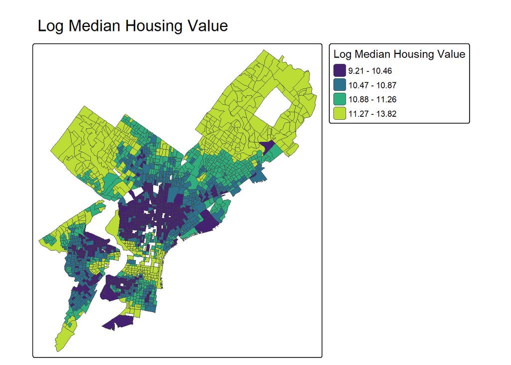

```r
map1 <- tm_shape(regression_data_shp) +
  tm_polygons(
    fill = "LNMEDHVAL",
    fill.scale = tm_scale_intervals(
      style = "quantile",
      n = 4,
      values = "viridis"
    ),
    fill.legend = tm_legend(
      title = "Log Median Housing Value"
      ),
    lwd = 0.2
  ) +
  tm_title("Log Median Housing Value") +
  tm_layout(legend.outside = TRUE)

map1
```

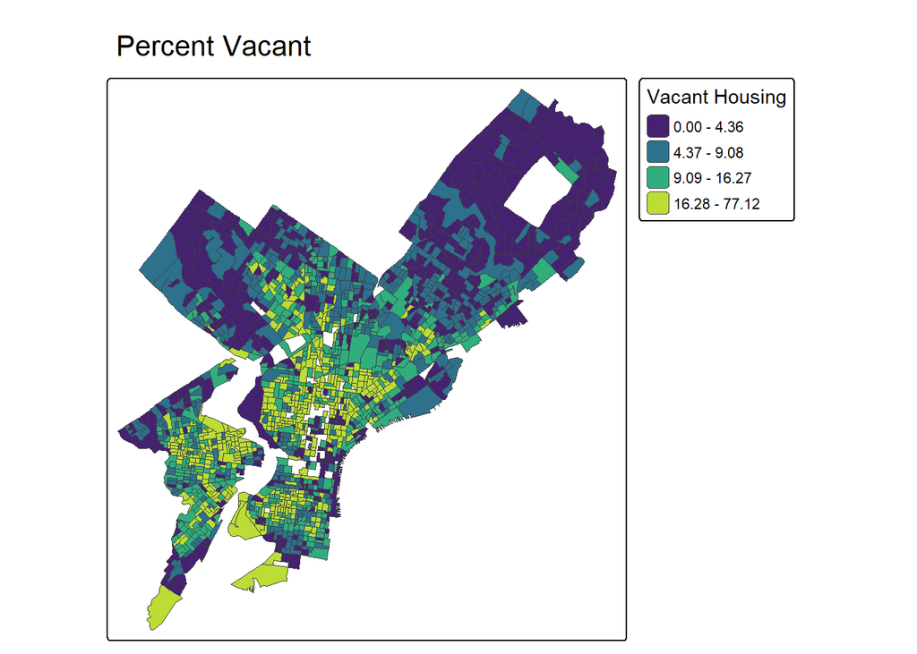

```r
# create the predictor maps

map2 <- tm_shape(regression_data_shp) +
  tm_polygons(
    fill = "PCTVACANT",
    fill.scale = tm_scale_intervals(
      style = "quantile", n = 4, values = "viridis"
    ),
    fill.legend = tm_legend(
      title = "Vacant Housing"
      ),
    lwd = 0.1
  ) +
  tm_title("Percent Vacant")

map3 <- tm_shape(regression_data_shp) +
  tm_polygons(
    fill = "PCTSINGLES",
    fill.scale = tm_scale_intervals(
      style = "quantile", n = 4, values = "viridis"
    ),
    fill.legend = tm_legend(
      title = "Single-Family Housing"
      ),
    lwd = 0.1
  ) +
  tm_title("Percent Single-Family")

map4 <- tm_shape(regression_data_shp) +
  tm_polygons(
    fill = "PCTBACHMOR",
    fill.scale = tm_scale_intervals(
      style = "quantile", n = 4, values = "viridis"
    ),
    fill.legend = tm_legend(
      title = "Bachelor's Degree or Higher"
      ),
    lwd = 0.1
  ) +
  tm_title("Percent Bachelor's Degree or Higher")

regression_data_shp$LNNBELPOV100 <- LNNBELPOV100
map5 <- tm_shape(regression_data_shp) +
  tm_polygons(
    fill = "LNNBELPOV100",
    fill.scale = tm_scale_intervals(
      style = "quantile", n = 4, values = "viridis"
    ),
    fill.legend = tm_legend(
      title = "Log Households Below Poverty"
      ),
    lwd = 0.1
  ) +
  tm_title("Log Households Below Poverty")

map2
```

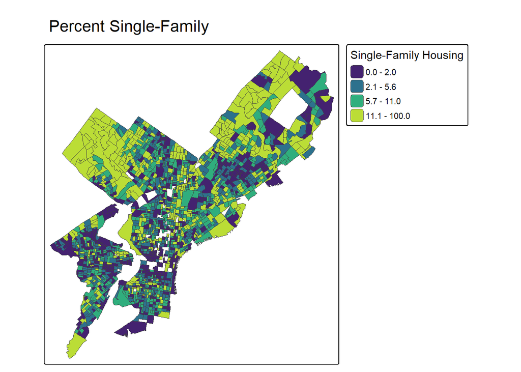

```r
map3
```

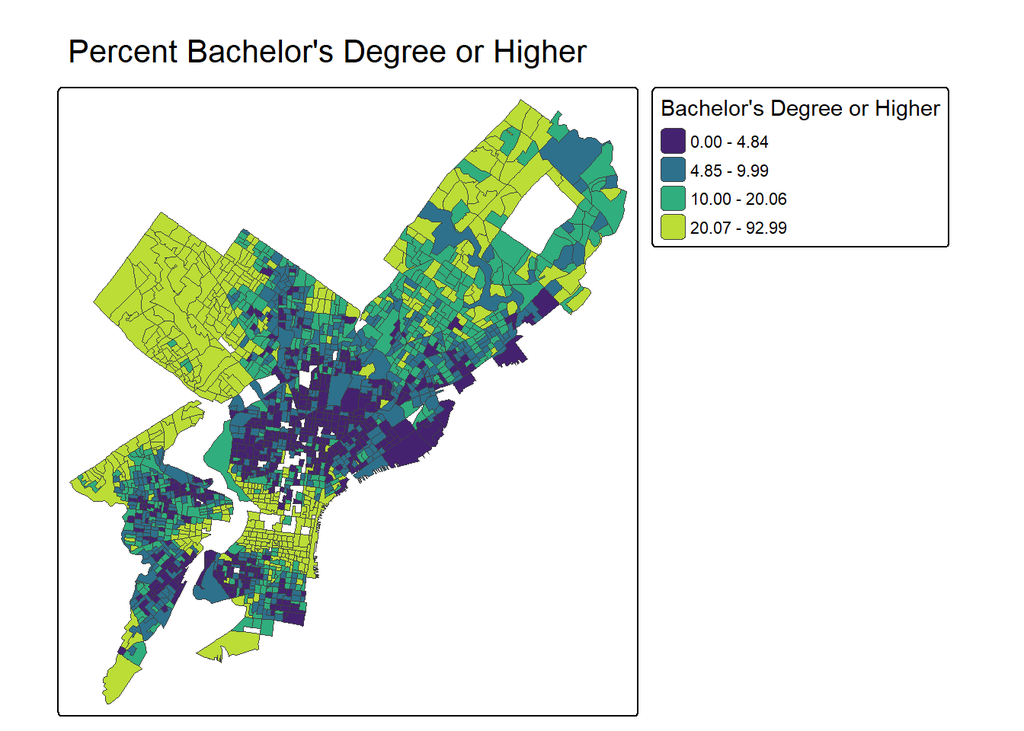

```r
map4
```

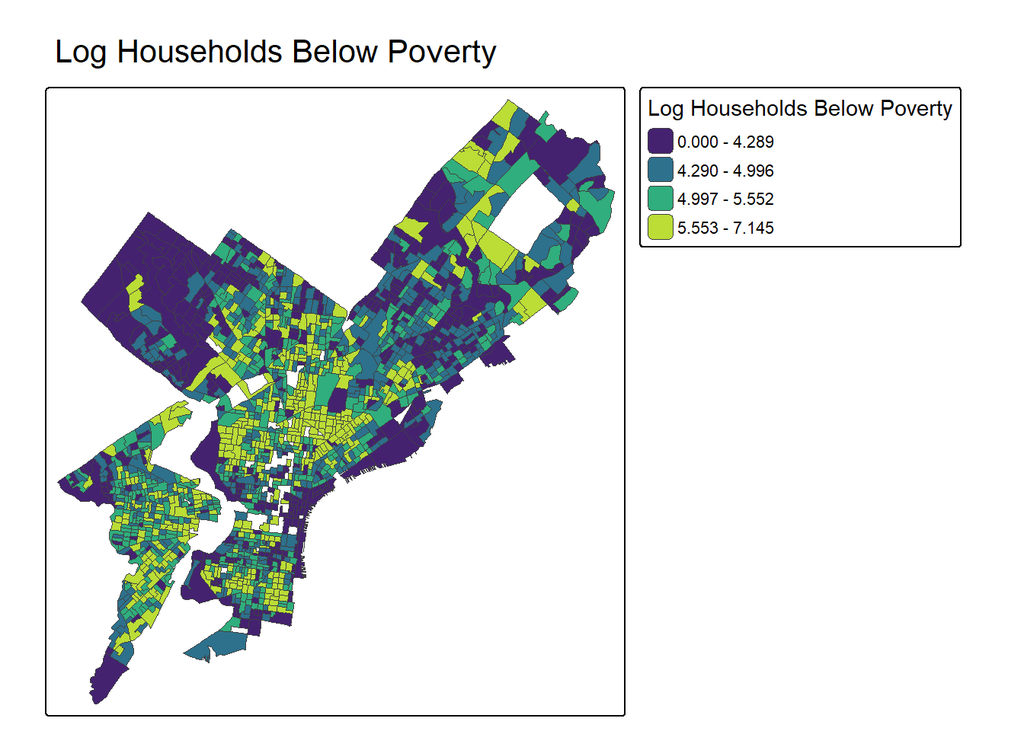

```r
map5
```

[output not shown]

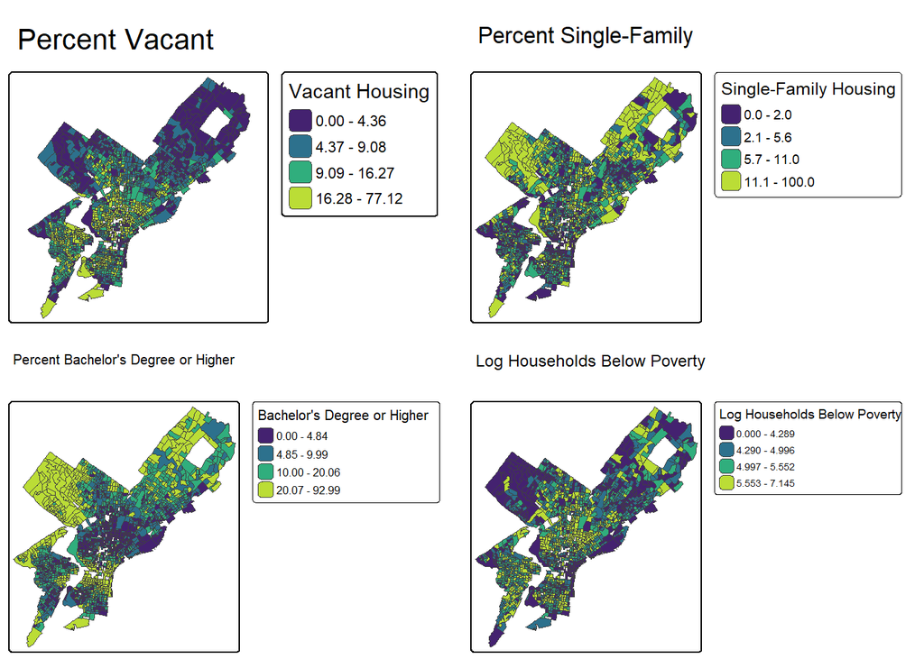

```r
# create figures for the predictor maps

predictor_maps <- tmap_arrange(
  map2, map3, map4, map5,
  ncol = 2,
  nrow = 2
)

predictor_maps
```

```r
# save the figures

tmap_save(
  predictor_maps,
  filename = "predictor_maps.png",
  width = 10,
  height = 8,
  units = "in",
  dpi = 300
)
```

```
## [plot mode] fit legend/component: Some legend items or map compoments do not
## fit well, and are therefore rescaled.
## ℹ Set the tmap option `component.autoscale = FALSE` to disable rescaling.
## [plot mode] fit legend/component: Some legend items or map compoments do not
## fit well, and are therefore rescaled.
## ℹ Set the tmap option `component.autoscale = FALSE` to disable rescaling.
## Map saved to D:\00_MUSA_EVERTHING\MUSA_5000_Stats_HW\HW_1\MUSA_5000_Stats\Assignment 1\predictor_maps.png
##
## Resolution: 3000 by 2400 pixels
##
## Size: 10 by 8 inches (300 dpi)
```

```r
# save LNMEDHVAL figure

tmap_save(
  map1,
  filename = "LNMEDHVAL_map.png",
  width = 8,
  height = 6,
  units = "in",
  dpi = 300
)
```

```
## Map saved to D:\00_MUSA_EVERTHING\MUSA_5000_Stats_HW\HW_1\MUSA_5000_Stats\Assignment 1\LNMEDHVAL_map.png
## Resolution: 2400 by 1800 pixels
## Size: 8 by 6 inches (300 dpi)
```

```r
# regression analysis

regression <- lm(LNMEDHVAL ~ PCTVACANT + PCTSINGLES + PCTBACHMOR + LNNBELPOV100, data = regression_data)

regression
```

```
##
## Call:
## lm(formula = LNMEDHVAL ~ PCTVACANT + PCTSINGLES + PCTBACHMOR +
##     LNNBELPOV100, data = regression_data)
##
## Coefficients:
##  (Intercept)     PCTVACANT    PCTSINGLES    PCTBACHMOR  LNNBELPOV100
##    11.113766     -0.019157      0.002977      0.020910     -0.078905
```

```r
# summary table

summary(regression)
```

```
##
## Call:
## lm(formula = LNMEDHVAL ~ PCTVACANT + PCTSINGLES + PCTBACHMOR +
##     LNNBELPOV100, data = regression_data)
##
## Residuals:
##      Min       1Q   Median       3Q      Max
## -2.25825 -0.20391  0.03822  0.21744  2.24347
##
## Coefficients:
##                Estimate Std. Error t value             Pr(>|t|)
## (Intercept)  11.1137661  0.0465330 238.836 < 0.0000000000000002 ***
## PCTVACANT    -0.0191569  0.0009779 -19.590 < 0.0000000000000002 ***
## PCTSINGLES    0.0029769  0.0007032   4.234            0.0000242 ***
## PCTBACHMOR    0.0209098  0.0005432  38.494 < 0.0000000000000002 ***
## LNNBELPOV100 -0.0789054  0.0084569  -9.330 < 0.0000000000000002 ***
## ---
## Signif. codes:  0 '***' 0.001 '**' 0.01 '*' 0.05 '.' 0.1 ' ' 1
##
## Residual standard error: 0.3665 on 1715 degrees of freedom
## Multiple R-squared:  0.6623, Adjusted R-squared:  0.6615
## F-statistic: 840.9 on 4 and 1715 DF,  p-value: < 0.00000000000000022
```

```r
# ANOVA table

anova(regression)
```

```
## Analysis of Variance Table
##
## Response: LNMEDHVAL
##                Df  Sum Sq Mean Sq  F value                Pr(>F)
## PCTVACANT       1 180.392 180.392 1343.087 < 0.00000000000000022 ***
## PCTSINGLES      1  24.543  24.543  182.734 < 0.00000000000000022 ***
## PCTBACHMOR      1 235.118 235.118 1750.551 < 0.00000000000000022 ***
## LNNBELPOV100    1  11.692  11.692   87.054 < 0.00000000000000022 ***
## Residuals    1715 230.344   0.134
## ---
## Signif. codes:  0 '***' 0.001 '**' 0.01 '*' 0.05 '.' 0.1 ' ' 1
```

```r
regression_predicted <- fitted(regression)
regression_residuals <- residuals(regression)
regression_standardresiduals <- rstandard(regression)

regression_predicted
```

[output not shown]

[output cut: 375 more lines]

[output not shown]

```r
regression_residuals
```

[output not shown]

[output cut: 633 more lines]

[output not shown]

```r
regression_standardresiduals
```

[output not shown]

[output cut: 633 more lines]

[output not shown]

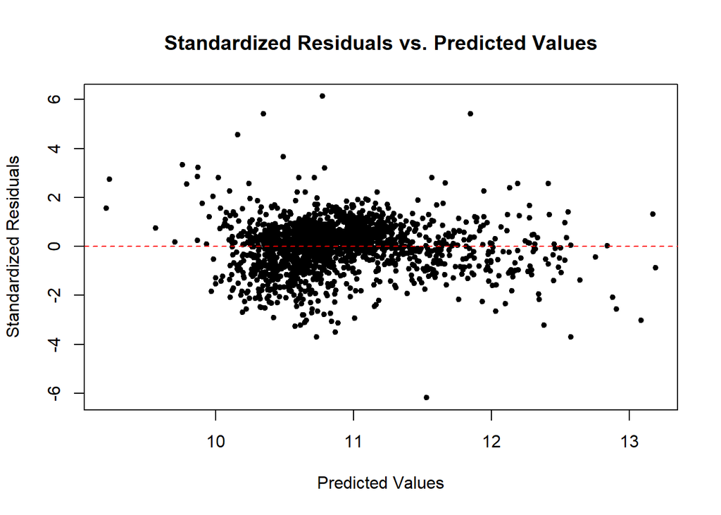

```r
# scatter plot of standardized residuals

plot(
  regression_predicted,
  regression_standardresiduals,
  xlab = "Predicted Values",
  ylab = "Standardized Residuals",
  main = "Standardized Residuals vs. Predicted Values",
  pch = 20
)

abline(h = 0, lty = 2, col = "red")
```

```r
# stepwise regression

step_regression <- stepAIC(regression, direction = "both")
```

```
## Start:  AIC=-3448.07
## LNMEDHVAL ~ PCTVACANT + PCTSINGLES + PCTBACHMOR + LNNBELPOV100
##
##                Df Sum of Sq    RSS     AIC
## <none>                      230.34 -3448.1
## - PCTSINGLES    1     2.407 232.75 -3432.2
## - LNNBELPOV100  1    11.692 242.04 -3364.9
## - PCTVACANT     1    51.546 281.89 -3102.7
## - PCTBACHMOR    1   199.020 429.36 -2379.0
```

```r
step_regression
```

```
##
## Call:
## lm(formula = LNMEDHVAL ~ PCTVACANT + PCTSINGLES + PCTBACHMOR +
##     LNNBELPOV100, data = regression_data)
##
## Coefficients:
##  (Intercept)     PCTVACANT    PCTSINGLES    PCTBACHMOR  LNNBELPOV100
##    11.113766     -0.019157      0.002977      0.020910     -0.078905
```

```r
step_regression$anova
```

```
## Stepwise Model Path
## Analysis of Deviance Table
##
## Initial Model:
## LNMEDHVAL ~ PCTVACANT + PCTSINGLES + PCTBACHMOR + LNNBELPOV100
##
## Final Model:
## LNMEDHVAL ~ PCTVACANT + PCTSINGLES + PCTBACHMOR + LNNBELPOV100
##
##
##   Step Df Deviance Resid. Df Resid. Dev       AIC
## 1                       1715   230.3435 -3448.073
```

```r
AIC(step_regression)
```

```
## [1] 1435.075
```

```r
# k fold validation
regression_data$LNNBELPOV100 <- LNNBELPOV100
cv1 <- CVlm(
  data = regression_data,
  form.lm = formula(regression),
  m = 5,
  plotit = FALSE
)
```

```
##
## fold 1
## Observations in test set: 344
##                     20         27         32        35          36         44
## Predicted   12.5446791 12.1908340 11.7943923 11.946024 12.00900782 12.1314071
## cvpred      12.5505271 12.1956021 11.7967462 11.951460 12.01051260 12.1329055
## LNMEDHVAL   12.6723192 12.1291916 11.6055046 12.385055 11.99843328 13.0049303
## CV residual  0.1217921 -0.0664105 -0.1912415  0.433595 -0.01207932  0.8720248
##                       45          64        67         69          70
## Predicted   11.403737703 12.26410114 12.168848 11.7284995 11.62021519
## cvpred      11.405000627 12.27637776 12.177464 11.7326978 11.62627345
## LNMEDHVAL   11.400875961 12.32385568 11.918391 11.9652742 11.67843990
## CV residual -0.004124665  0.04747792 -0.259073  0.2325763  0.05216646
##                     72        75         88          89         91         92
## Predicted   11.5973031 10.345476 10.5490288 10.64651696 10.9844744 10.4049343
## cvpred      11.6047281 10.343032 10.5457388 10.65156220 10.9859876 10.4037289
## LNMEDHVAL   11.4031106 12.323856 10.1345993 10.63103616 10.7600283 11.0020998
## CV residual -0.2016175  1.980824 -0.4111395 -0.02052604 -0.2259593  0.5983709
##                    110        117        124        126         129        140
## Predicted   10.7567030 10.5185287 10.6773466 10.6534219 10.94306876 10.5827600
## cvpred      10.7516835 10.5134579 10.6756050 10.6487618 10.94605256 10.5769483
## LNMEDHVAL   11.2424282 10.6213273 11.0728689 10.8930287 10.87426647 10.4659564
## CV residual  0.4907447  0.1078695  0.3972639  0.2442669 -0.07178609 -0.1109919
##                    141        142        148         154       158       159
## Predicted   10.5056839 10.2895549 10.5723541 10.36685107 10.809322 11.526857
## cvpred      10.5006335 10.2865381 10.5692504 10.36721675 10.808813 11.530235
## LNMEDHVAL   10.6286178 10.5400644 10.3189030 10.42821608 10.069002  9.268609
## CV residual  0.1279843  0.2535263 -0.2503474  0.06099933 -0.739811 -2.261626
##                    161        166         180         184       193        197
## Predicted   10.1171207 10.5407087 10.43507436 10.61636443 10.666739 10.8287808
## cvpred      10.1109623 10.5384357 10.42925672 10.61195517 10.665694 10.8308029
## LNMEDHVAL    9.6927665  9.8934372 10.50232405 10.63585545 10.992050 11.1995836
## CV residual -0.4181957 -0.6449985  0.07306733  0.02390028  0.326356  0.3687808
##                    202        203       234         246         250        252
## Predicted   10.7710263 10.7169028 10.784298 10.56525496 10.78440771 10.8088821
## cvpred      10.7724847 10.7168394 10.786129 10.56377199 10.78510311 10.8107551
## LNMEDHVAL   11.0898054 11.0697585  9.769956 10.60162227 10.72546760 10.6942151
## CV residual  0.3173207  0.3529191 -1.016173  0.03785028 -0.05963551 -0.1165401
##                     253          255          256        265        267
## Predicted   10.67336482 10.507470132 10.495926598 10.7983661 10.5007421
```

[output cut: 1464 more lines]

[output not shown]

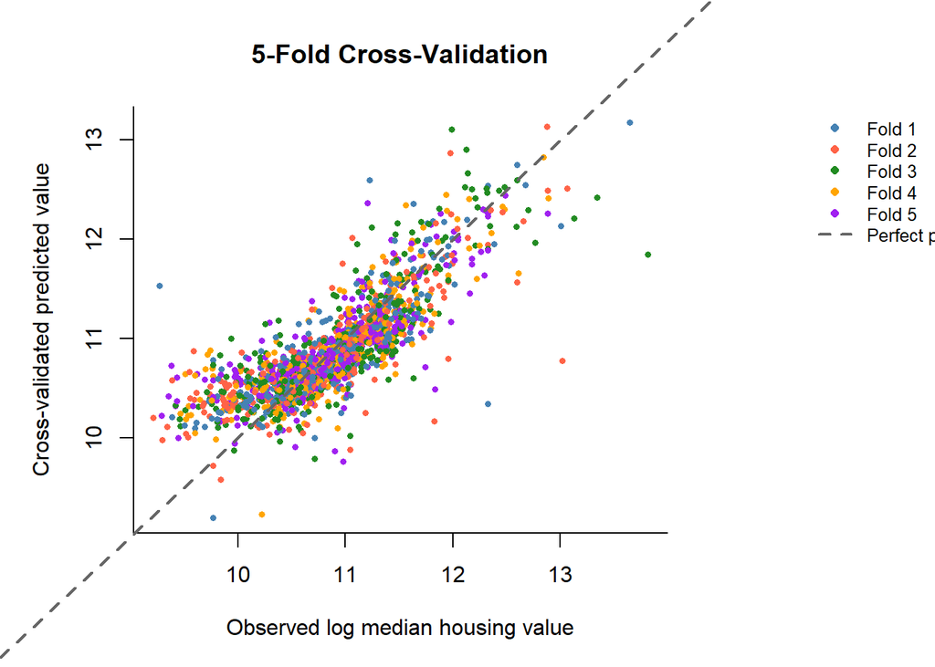

```r
# format
# Create plot data
plot_data <- data.frame(
  Observed = cv1$LNMEDHVAL,
  Predicted = cv1$cvpred,
  Fold = factor(cv1$fold)
)

# Assign a different color to each fold
fold_colors <- c("steelblue", "tomato", "forestgreen", "orange", "purple")

# Leave space on the right for the legend
par(mar = c(5, 5, 4, 10), xpd = TRUE)

# Plot observed versus predicted values
plot(
  plot_data$Observed,
  plot_data$Predicted,
  pch = 16,
  cex = 0.6,
  col = fold_colors[as.numeric(plot_data$Fold)],
  xlab = "Observed log median housing value",
  ylab = "Cross-validated predicted value",
  main = "5-Fold Cross-Validation",
  bty = "l"
)

# Reference line for perfect predictions
abline(0, 1, lty = 2, lwd = 2, col = "gray40")

# Legend on the right
legend(
  "topright",
  inset = c(-0.65, 0),
  legend = c(paste("Fold", 1:5), "Perfect prediction"),
  col = c(fold_colors, "gray40"),
  pch = c(rep(16, 5), NA),
  lty = c(rep(NA, 5), 2),
  lwd = c(rep(NA, 5), 2),
  bty = "n",
  cex = 0.8
)
```

```r
par(xpd = FALSE)


rmse1 <- sqrt(mean(
  (cv1$LNMEDHVAL - cv1$cvpred)^2,
  na.rm = TRUE
))

rmse1
```

```
## [1] 0.3664401
```

```r
# second cross validation

# Create the second regression model with only two predictors
regression2 <- lm(
  LNMEDHVAL ~ PCTVACANT + MEDHHINC,
  data = regression_data
)

# Run 5-fold cross-validation
cv2 <- CVlm(
  data = regression_data,
  form.lm = formula(regression2),
  m = 5,
  plotit = FALSE
)
```

```
##
## fold 1
## Observations in test set: 344
##                    20         27         32       35         36        44
## Predicted   11.557499 11.6828812 10.9620047 11.34662 11.0407941 10.951747
## cvpred      11.556902 11.6823824 10.9651308 11.35033 11.0438758 10.951971
## LNMEDHVAL   12.672319 12.1291916 11.6055046 12.38506 11.9984333 13.004930
## CV residual  1.115417  0.4468092  0.6403739  1.03473  0.9545575  2.052959
##                     45         64         67         69         70         72
## Predicted   10.9365417 11.4224071 11.7159745 11.1322431 11.2878702 11.0014339
## cvpred      10.9394338 11.4240965 11.7170639 11.1326079 11.2919880 11.0037815
## LNMEDHVAL   11.4008760 12.3238557 11.9183906 11.9652742 11.6784399 11.4031106
## CV residual  0.4614421  0.8997592  0.2013267  0.8326663  0.3864519  0.3993291
##                    75        88         89         91         92        110
## Predicted   10.278641 10.333066 10.8045985 11.0355314 10.2723058 10.7137237
## cvpred      10.277580 10.335727 10.8079252 11.0364185 10.2735066 10.7153836
## LNMEDHVAL   12.323856 10.134599 10.6310362 10.7600283 11.0020998 11.2424282
## CV residual  2.046276 -0.201128 -0.1768891 -0.2763902  0.7285932  0.5270446
##                    117        124        126        129        140        141
## Predicted   10.4162208 10.8514124 10.6906174 10.6914759 10.6469488 10.5022005
## cvpred      10.4210502 10.8551366 10.6956995 10.6976391 10.6520612 10.5083807
## LNMEDHVAL   10.6213273 11.0728689 10.8930287 10.8742665 10.4659564 10.6286178
## CV residual  0.2002772  0.2177323  0.1973292  0.1766274 -0.1861048  0.1202371
##                    142        148         154        158       159        161
## Predicted   10.6554315 10.4889888 10.32945158 10.9281180 10.609053 10.3449596
## cvpred      10.6549749 10.4934901 10.33331050 10.9308298 10.617973 10.3452670
## LNMEDHVAL   10.5400644 10.3189030 10.42821608 10.0690020  9.268609  9.6927665
## CV residual -0.1149105 -0.1745871  0.09490558 -0.8618279 -1.349364 -0.6525005
##                    166        180       184         193         197        202
## Predicted   10.8433109 10.8004300 10.802652 10.95604859 11.10165597 10.8509371
## cvpred      10.8451230 10.8036235 10.807940 10.95980398 11.10521897 10.8560628
## LNMEDHVAL    9.8934372 10.5023241 10.635855 10.99204951 11.19958365 11.0898054
## CV residual -0.9516858 -0.3012994 -0.172085  0.03224552  0.09436467  0.2337426
##                    203        234      246        250        252        253
## Predicted   10.7973676 10.5053517 10.79074 10.9131281 10.9032730 10.8399546
## cvpred      10.7999508 10.5045736 10.79469 10.9169181 10.9074717 10.8433052
## LNMEDHVAL   11.0697585  9.7699562 10.60162 10.7254676 10.6942151 10.7298536
## CV residual  0.2698077 -0.7346175 -0.19307 -0.1914505 -0.2132567 -0.1134516
##                     255        256        265       267        275         280
## Predicted   10.59868255 10.6932027 10.8748098 10.751864 10.5061073 10.99170923
```

[output cut: 1464 more lines]

```
## Predicted   11.2892248 11.18774 10.9666797 11.027649 11.209920 11.5802348
## cvpred      11.2804489 11.17868 10.9601662 11.020075 11.201803 11.5684238
## LNMEDHVAL   11.5287988 11.45952 11.6045927 11.524854 11.661345 11.3736634
## CV residual  0.2483499  0.28084  0.6444264  0.504779  0.459542 -0.1947604
##                  1704       1706
## Predicted   11.385843 11.8114077
## cvpred      11.375951 11.7970672
## LNMEDHVAL   11.491702 11.4637352
## CV residual  0.115751 -0.3333319
##
## Sum of squares = 76.8    Mean square = 0.22    n = 344
##
## Overall (Sum over all 344 folds)
##        ms
## 0.1960024
```

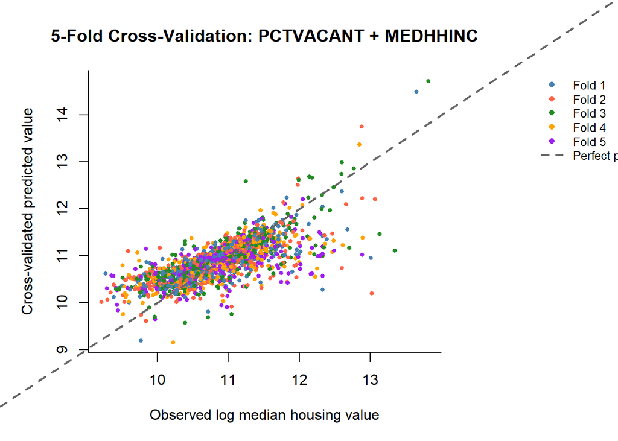

```r
# Format the cross-validation results
plot_data <- data.frame(
  Observed = cv2$LNMEDHVAL,
  Predicted = cv2$cvpred,
  Fold = factor(cv2$fold)
)

# Assign a different color to each fold
fold_colors <- c("steelblue", "tomato", "forestgreen", "orange", "purple")

# Leave space on the right for the legend
par(mar = c(5, 5, 4, 10), xpd = TRUE)

# Plot observed versus predicted values
plot(
  plot_data$Observed,
  plot_data$Predicted,
  pch = 16,
  cex = 0.6,
  col = fold_colors[as.numeric(plot_data$Fold)],
  xlab = "Observed log median housing value",
  ylab = "Cross-validated predicted value",
  main = "5-Fold Cross-Validation: PCTVACANT + MEDHHINC",
  bty = "l"
)

# Reference line for perfect predictions
abline(0, 1, lty = 2, lwd = 2, col = "gray40")

# Legend on the right
legend(
  "topright",
  inset = c(-0.65, 0),
  legend = c(paste("Fold", 1:5), "Perfect prediction"),
  col = c(fold_colors, "gray40"),
  pch = c(rep(16, 5), NA),
  lty = c(rep(NA, 5), 2),
  lwd = c(rep(NA, 5), 2),
  bty = "n",
  cex = 0.8
)
```

```r
par(xpd = FALSE)

# Calculate RMSE
rmse2 <- sqrt(mean(
  (cv2$LNMEDHVAL - cv2$cvpred)^2,
  na.rm = TRUE
))

rmse2
```

```
## [1] 0.4427216
```

cross validation 1 RMSE: 0.3664401 cross validation 2 RMSE: 0.4427216

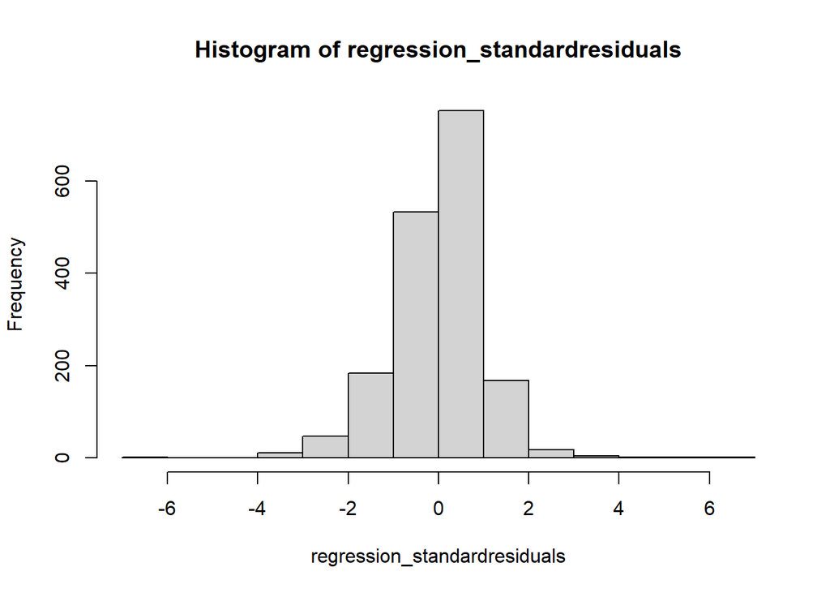

```r
hist(regression_standardresiduals)
```

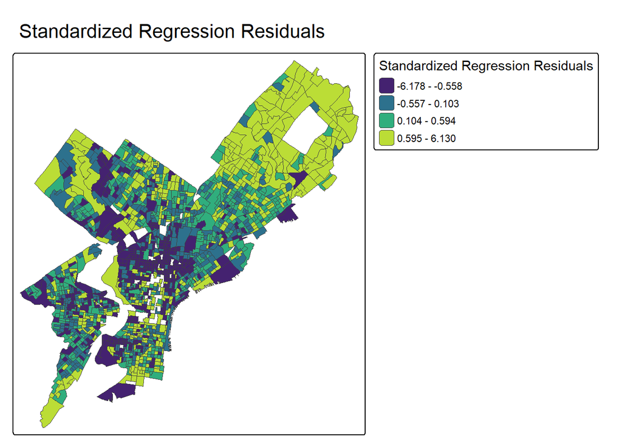

```r
regression_data_shp$regression_standardresiduals <-
  rstandard(regression)
map6 <- tm_shape(regression_data_shp) +
  tm_polygons(
    fill = "regression_standardresiduals",
    fill.scale = tm_scale_intervals(
      style = "quantile", n = 4, values = "viridis"
    ),
    fill.legend = tm_legend(
      title = "Standardized Regression Residuals"
      ),
    lwd = 0.1
  ) +
  tm_title("Standardized Regression Residuals")

map6
```

## REPORT - Draft by Wednesday, Submit Friday

## 1.1 INTRODUCTION

In this analysis, we examined the relationship between Philadelphia median house values and several neighborhood characteristics using census block-level data. We measured the relationship by regressing median house value on the following variables:

*Proportion of housing units that are vacant

*Percent of housing units that are detached single family houses

*Number of households with incomes below 100% poverty level

The regression output tells us that the there is a significant relationship between our dependent variable (Median house value) and each predictor (PCTVACANT, PCTSINGLES, PCTBACHMORE, and LNNBELPOV100). Holding all other variables constant:

*A 1 percentage point increase in PCTVACANT is associated with a 1.9% decrease in median house value (p-value < 0.0000000000000002)

*A 1 percentage point increase PCTSINGLES is associated with a .29% increase in median house value (p-value = .0000242)

*A 1 percentage point increase in PCTBACHMORE is associated with a 2% increase in median house value (p-value < 0.0000000000000002)

Each of these variables has a p-value well below .05, meaning that we can confidently say that if there is actually no relationship in the population between the dependent variable and each of the independent variables, then the probability of getting sample beta coefficients this extreme is less than the associated p-value.

These low probabilities illustrate that we can safely reject
$$\begin{aligned}
H_0&: \beta_1 = 0 \quad \text{for} \quad H_a: \beta_1 \neq 0 \\
H_0&: \beta_2 = 0 \quad \text{for} \quad H_a: \beta_2 \neq 0 \\
H_0&: \beta_3 = 0 \quad \text{for} \quad H_a: \beta_3 \neq 0 \\
H_0&: \beta_4 = 0 \quad \text{for} \quad H_a: \beta_4 \neq 0
\end{aligned}$$

About 66% of the variance in the dependent variable is explained by the model ($R^2$ and adjusted $R^2$ are 0.6623 and 0.6615, respectively). The low p-value associated with the F-ratio of 840.86 illustrates that we can reject the null hypothesis that all coefficients in the model are 0.

Peer-reviewed studies suggest a positive relationship between median house value and median household income, and neighborhoods with clustered college graduates (Harvard University, US Census, National Bureau of Economic Research) . We want to examine a broader set of variables and their relationship to median house value.

Historically, single-family homes are clustered in areas with higher median house value. Starting in the 1930s, racist redlining and zoning practices became commonplace across the country, with the intention of maintaining segregated neighborhoods, denying Black and brown families a path to generational wealth accumulation, and displacing historically Black and brown neighborhoods. As a result, white and wealthy neighborhoods, typically with a large concentration of single-family homes, higher rates of education, and higher median household income, were protected from harmful redevelopment such as the bisection of communities through highway development and eminent domain of homes and businesses. Meanwhile, Black and brown communities were subject to significant displacement and deliberately denied access to homeownership and property value appreciation, the effects of which we still see today. Although race is not a variable in our model, Philadelphia’s history of redlining and Urban Renewal contributed to the economically stratified neighborhood patterns we see in this model. The history of redlining and displacement does not disaggregate race from class; in fact, the impact of these policies were racist in their institutional denial of upward mobility in marginalized communities and classed in their racialization. Policies such as redlining and urban renewal were framed as economic revitalization initiatives, but in practice, they resulted in the disinvestment of Black and brown neighborhoods, making poor neighborhoods poorer and wealthy neighborhoods wealthier. The predictors we evaluate are likely related to our response variable because they stem from the same historical processes that shaped the residential construction of Philadelphia and much of our country.

## 1.2 METHODS

### 1.2.1 Data Cleaning

This analysis uses 2000 Census data for Philadelphia at the block group level. The original dataset contained 1,816 block groups. Four categories of observations were removed before the data were released for analysis: block groups with a population below 40, block groups with no housing units, block groups with a median house value below $10,000, and one North Philadelphia block group reporting a median house value above $800,000 alongside a median household income below $8,000. In each case the records would have produced unstable or implausible estimates, whether because a median drawn from very few households is easily distorted, because no housing market exists to measure, or because the reported values are inconsistent with the rest of the city.

The cleaned dataset contains 1,720 block groups. No further outlier screening was carried out here, and all analyses that follow are based on these 1,720 observations.

### 1.2.2 Exploratory Data Analysis

#### 1.2.2.1 Summary statistics and distributions

Before fitting any model, we examine the summary statistics and distributions of the dependent variable and each predictor. For every variable we calculate the mean and the standard deviation, and we plot a histogram to assess the shape of its distribution. Where a distribution is strongly skewed, we apply a natural log transformation and re-examine the histogram to determine whether the transformed variable is better behaved than the original. Variables containing zero values are transformed as the natural log of one plus the variable, since the log of zero is undefined. We also plot the dependent variable against each predictor to assess whether the relationships appear linear, and we map the dependent variable and the predictors across the city to look for spatial patterns.

#### 1.2.2.2 Correlations between predictors

As part of this exploratory stage we also examine the correlations between the predictors. A correlation measures the strength and direction of the linear association between two variables, that is, whether they tend to move together, move in opposite directions, or show no consistent linear pattern at all. The sample correlation coefficient $r$ can be written as the average product of the standardized deviations of the two variables,

$$r = \frac{1}{n-1}\sum_{i=1}^{n}
\left( \frac{x_{i} - \bar{x}}{s_{x}} \right)
\left( \frac{y_{i} - \bar{y}}{s_{y}} \right)
\tag{1}$$

where

$$\begin{aligned}
r &= \text{sample correlation coefficient} \\
n &= \text{number of observations, here the 1,720 block groups} \\
x_{i},\, y_{i} &= \text{values of the two variables for observation
} i \\
\bar{x},\, \bar{y} &= \text{sample means of } x \text{ and } y \\
s_{x},\, s_{y} &= \text{sample standard deviations of } x \text{ and
} y
\end{aligned}$$

Because each deviation from the mean is divided by the standard deviation of its own variable, $r$ is unitless and can be compared across variables measured on entirely different scales.

The correlation coefficient ranges from $-1$ to $+1$. A value of $+1$ indicates a perfect positive linear relationship, in which the two variables increase together in exact proportion, and a value of $-1$ indicates a perfect negative linear relationship, in which one increases exactly as the other decreases. A correlation of 0 means there is no linear association between the two variables, though it does not rule out a relationship of some other, non-linear form.

We examine these correlations because strongly inter-correlated predictors create multicollinearity, which makes it difficult for the regression to isolate the individual contribution of each predictor and leaves the coefficient estimates unstable. A correlation greater than $|0.8|$ between a pair of predictors would indicate severe multicollinearity and call for dropping one of them. The dependent variable is deliberately excluded from this check, since a strong correlation between a predictor and the dependent variable is desirable rather than problematic.

### 1.2.3 Multiple Regression Analysis

#### 1.2.3.1 The method

Multiple regression is used to model the relationship between a single continuous dependent variable and a set of predictors. It estimates a linear equation that describes how the dependent variable changes as each predictor changes, and it does so for all predictors simultaneously rather than one at a time. The result is a coefficient for each predictor that represents its association with the dependent variable while the remaining predictors are held constant, which allows the individual contribution of each predictor to be isolated. The fitted equation can then be used both to interpret those relationships and to generate predicted values for observations in the data.

#### 1.2.3.2 The model

For this analysis, the dependent variable is the natural log of median house value, and the model is

$$\begin{aligned}
\text{LNMEDHVAL} = \ &\beta_{0}
+ \beta_{1}\,\text{PCTVACANT}
+ \beta_{2}\,\text{PCTSINGLES} \\[4pt]
&+ \beta_{3}\,\text{PCTBACHMOR}
+ \beta_{4}\,\text{LNNBELPOV100}
+ \varepsilon
\end{aligned}
\tag{2}$$

where

$$\begin{aligned}
\text{LNMEDHVAL} &= \text{natural log of median house value} \\
\text{PCTVACANT} &= \text{percent of housing units that are vacant}
\\
\text{PCTSINGLES} &= \text{percent of housing units that are
detached single family homes} \\
\text{PCTBACHMOR} &= \text{percent of residents with at least a
bachelor's degree} \\
\text{LNNBELPOV100} &= \text{natural log of one plus the number of
households in poverty} \\
\beta_{0} &= \text{the intercept, the expected value of LNMEDHVAL
when all predictors equal zero} \\
\beta_{1} \ldots \beta_{4} &= \text{the slope coefficients, each
giving the expected change in} \\
&\quad \ \text{LNMEDHVAL for a one unit increase in its predictor,
holding the others constant} \\
\varepsilon &= \text{the error term, the portion of LNMEDHVAL not
explained by the predictors}
\end{aligned}$$

Both the dependent variable and the poverty predictor are log transformed. The remaining three predictors enter the model untransformed, so their coefficients describe the effect of a one percentage point increase in each.

#### 1.2.3.3 Assumptions

**Linearity.** The relationship between each predictor and the dependent variable is assumed to be linear. If the true relationship curves, a straight line will misstate the effect across parts of the range.

**Independence of observations.** Each observation is assumed to be independent of every other. With spatial data this assumption is often questionable, since nearby block groups may resemble one another, a condition known as spatial autocorrelation.

**Normality of residuals.** The errors are assumed to be normally distributed with a mean of zero. Note that this applies to the residuals rather than to the raw variables, which need not be normal themselves.

### 1.2.4 Additional Analyses

#### 1.2.4.1 Stepwise regression

Stepwise regression automates the choice of which predictors to retain. Starting from a specified model, the algorithm adds or removes one predictor at a time and scores each candidate model using the Akaike Information Criterion, a measure that balances fit against the number of predictors used. Fitting better lowers the score and each additional predictor raises it, so a predictor earns its place only if the improvement outweighs the added complexity. Lower is better, and the value means something only in comparison with other models. The procedure makes whichever move lowers the score most and stops when no further change improves it. We run it in both directions, so predictors may be either added or dropped.

Its limitations is as it searches many models against the same data and reports the winner, it is prone to overfitting, and the p-values for the selected model are optimistic since they ignore the search that produced it. It finds a model that cannot be improved by a single step, not necessarily the best one. It also ignores theory about which predictors should matter, so it is better treated as one piece of evidence than as a decision rule.

#### 1.2.4.2 K-fold cross-validation

Cross-validation assesses how well a model predicts observations it was not fitted on. This matters because a model is estimated using the full dataset and will necessarily fit that data reasonably well, which makes in-sample measures such as $R^{2}$ an optimistic guide to performance on new observations.

We use k-fold cross-validation with $k = 5$. The 1,720 block groups are divided at random into five roughly equal groups, or folds. The model is then fitted five times. On each repetition, four folds are used to estimate the coefficients and the remaining fold is held out, with the fitted model used to generate predictions for the held-out observations. Each fold serves as the held-out set exactly once, so every block group receives a prediction from a model that was estimated without it.

Model performance is summarized by the root mean square error, calculated from these cross-validated predictions:

$$RMSE = \sqrt{\frac{1}{n}\sum_{i=1}^{n}\left(y_{i} -
\hat{y}_{i}\right)^{2}}
\tag{9}$$

where

$$\begin{aligned}
n &= \text{the number of observations, here the 1,720 block groups}
\\
y_{i} &= \text{observed value of the dependent variable for
observation } i \\
\hat{y}_{i} &= \text{cross-validated predicted value for observation
} i
\end{aligned}$$

Each prediction error is squared so that positive and negative errors do not offset one another and so that larger errors carry disproportionate weight. These squared errors are averaged, and the square root returns the result to the units of the dependent variable, here log median house value. A lower RMSE indicates predictions closer to the observed values, so the measure is interpreted as the typical size of the model’s prediction error.

An individual RMSE value is not meaningful in isolation, since its scale depends on the units of the dependent variable. It is used instead to compare models fitted to the same dependent variable. We apply this procedure to the four predictor model specified above and to a reduced model containing only PCTVACANT and MEDHHINC as predictors, and compare the two resulting RMSE values.

### 1.2.5 Software

All analysis was carried out in R. Summary statistics, histograms, scatter plots, correlations, and the regression models were produced using base R functions, including `lm` for the regression and `cor` for the correlation matrix. The `MASS` package was used for the stepwise regression, the `DAAG` package for the k-fold cross-validation, and the `sf` and `tmap` packages for reading the shapefile and producing the choropleth maps.

The report itself was written in R Markdown, so the code, output, and text are contained in a single document.

## 1.3 RESULTS

### 1.3.1 Exploratory Results

```r
summary_table
```

```
##             Variable         Mean           SD
## 1 Dependent Variable           NA           NA
## 2            MEDHVAL 66287.733140 60006.075990
## 3         Predictors           NA           NA
## 4         PCTBACHMOR    16.081372    17.769558
## 5           MEDHHINC 31541.764535 16298.433836
## 6          PCTVACANT    11.288529     9.628472
## 7         PCTSINGLES     9.226473    13.249250
## 8         NBELPOV100   189.770930   164.318480
```

Many of the variables used in this study are not normal, so we completed a the logarithmic transformation for each variable in an attempt to normalize the data. The logarithmic transformation only normalizes MEDHVAL and NBELPOV100, whereas the other variables show a large spike at zero. The following histograms visualize the logarithmic transformations.

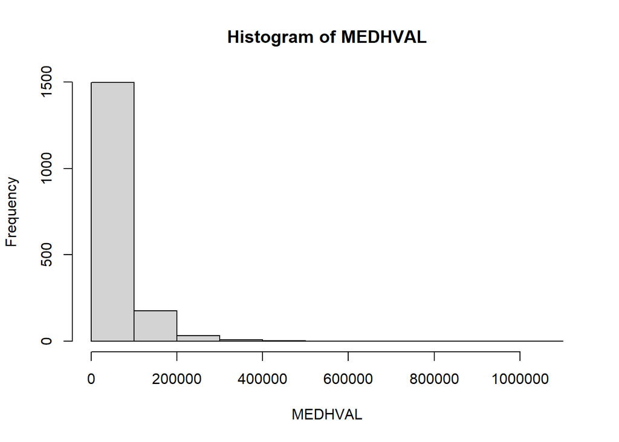

```r
hist(MEDHVAL)
```

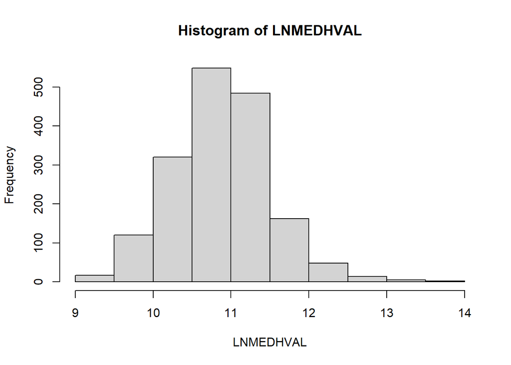

```r
hist(LNMEDHVAL)
```

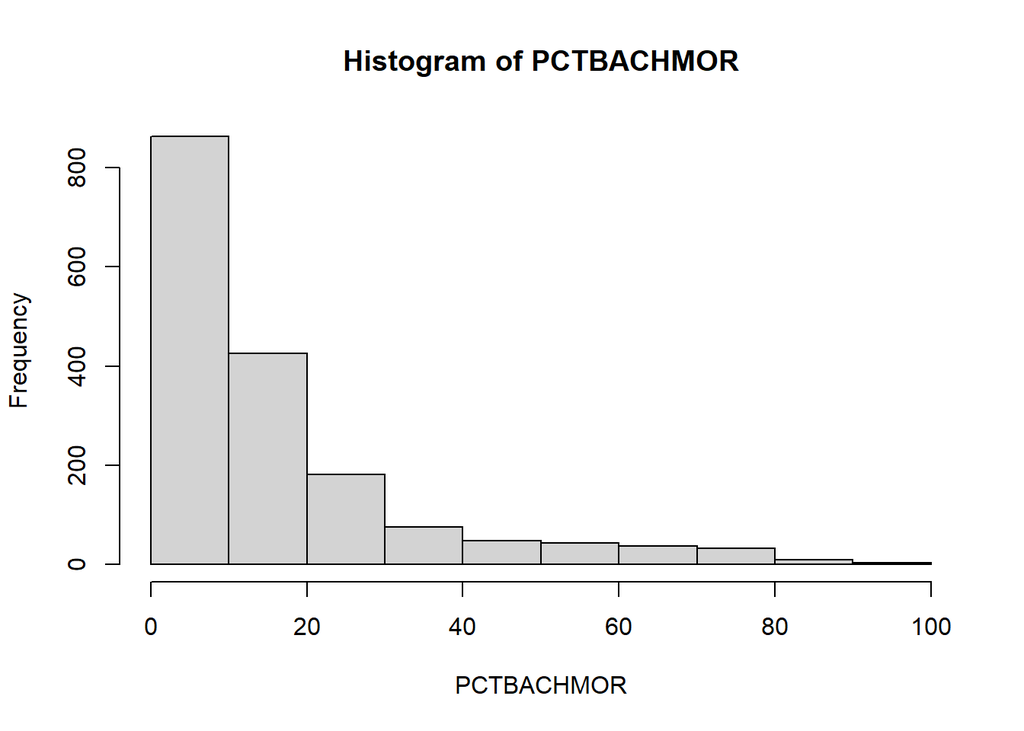

```r
hist(PCTBACHMOR)
```

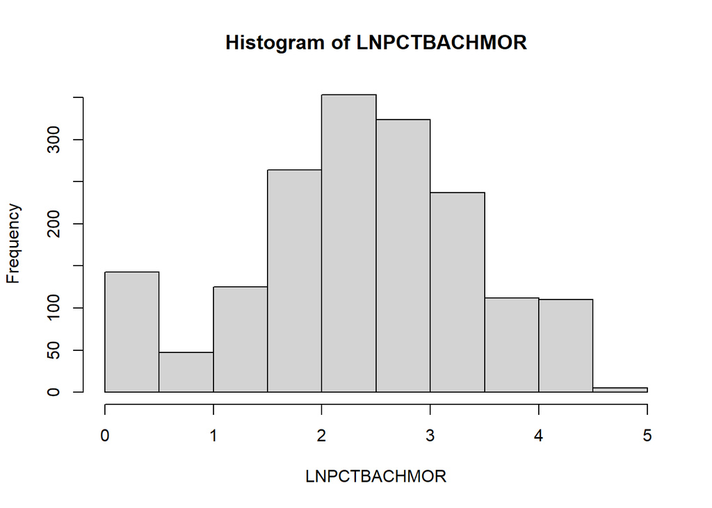

```r
hist(LNPCTBACHMOR)
```

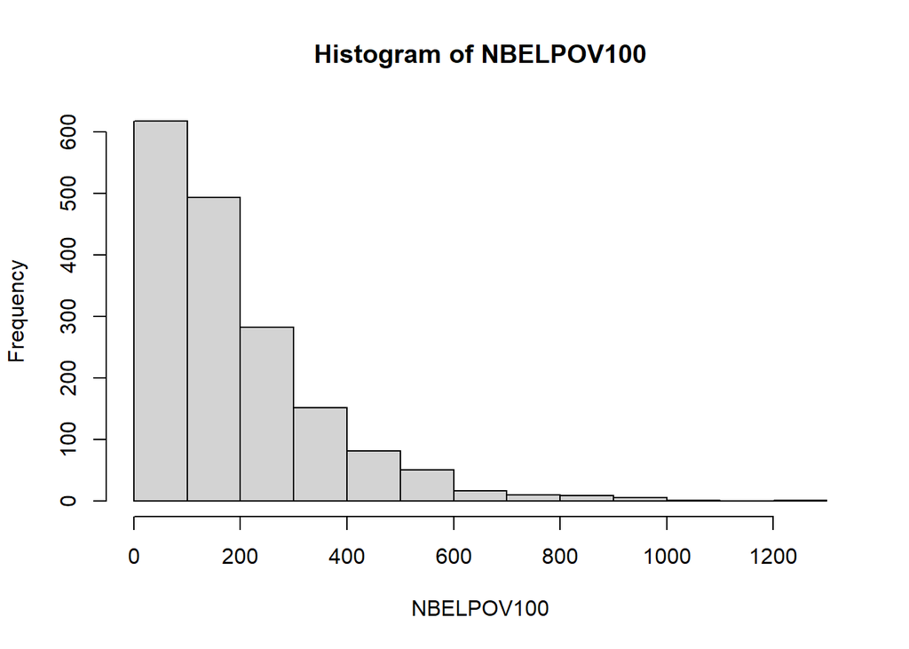

```r
hist(NBELPOV100)
```